# Assignment 3 R code

```r
library(tidyverse)
```

```
1: package ‘raster’ was built under R version 4.4.2
2: package ‘sp’ was built under R version 4.4.2
```

```r
library(haven)
library(stargazer)
df <- read_dta("cen_ind_2021_pumf_v2.dta")
head(df)
```

| ppsort | aboid | agegrp | ageimm | attsch | bfnmemb | bedrm | CFInc | CFInc_AT | cfstat | chdbn | CIP2021 | CIP2021_STEM_SUM | cma | condo | COVID_ERB | cow | cqppb | CapGn | CfSize | ChldC | CitOth | Citizen | dist | dpgrsum | dtype | EFDecile | EFInc | EFInc_AT | eicbn | … |
| --- | --- | --- | --- | --- | --- | --- | --- | --- | --- | --- | --- | --- | --- | --- | --- | --- | --- | --- | --- | --- | --- | --- | --- | --- | --- | --- | --- | --- | --- | --- |
| 1 | 6 | 13 | 7 | 1 | 0 | 4 | 30 | 27 | 2 | 88888888 | 7 | 3 | 999 | 0 | 1.0e+08 | 1 | 1.0e+08 | 1e+08 | 4 | 88888888 | 88 | 3 | 9 | 88 | 1 | 9 | 33 | 31 | 1.0e+08 | … |
| 22 | 6 | 10 | 99 | 1 | 0 | 5 | 30 | 28 | 4 | 99999999 | 4 | 6 | 933 | 0 | 1.0e+08 | 1 | 1.0e+08 | 1e+08 | 4 | 99999999 | 15 | 1 | 1 | 3 | 2 | 8 | 31 | 30 | 1.0e+08 | … |
| 101 | 6 | 19 | 99 | 1 | 0 | 4 | 23 | 22 | 2 | 99999999 | 1 | 9 | 999 | 0 | 1.0e+08 | 9 | 5.6e+03 | 1e+08 | 3 | 99999999 | 15 | 1 | 9 | 1 | 1 | 5 | 23 | 22 | 1.0e+08 | … |
| 192 | 6 | 13 | 99 | 1 | 0 | 5 | 1 | 1 | 2 | 99999999 | 10 | 8 | 933 | 0 | 1.0e+08 | 1 | 1.0e+08 | 6e+03 | 3 | 99999999 | 7 | 3 | 9 | 3 | 1 | 1 | 1 | 1 | 1.0e+08 | … |
| 260 | 6 | 15 | 99 | 1 | 0 | 3 | 31 | 29 | 2 | 99999999 | 8 | 2 | 539 | 0 | 6.6e+03 | 1 | 1.0e+08 | 1e+08 | 4 | 99999999 | 15 | 1 | 1 | 1 | 1 | 9 | 31 | 29 | 3.1e+03 | … |
| 264 | 6 | 1 | 99 | 9 | 0 | 2 | 12 | 12 | 4 | 99999999 | 99 | 99 | 537 | 1 | 1.0e+08 | 9 | 1.0e+08 | 1e+08 | 4 | 99999999 | 15 | 1 | 9 | 8 | 2 | 1 | 12 | 12 | 1.0e+08 | … |

## Data Filtering & Rationail

We start by excluding cases where `pkids` or `lfact` are not available or not applicable. Then we create a binary `Retired` variable based on `lfact` codes 11, 12, and 13.

```r
df <- df %>%
  # 1) Exclude PKIDS = 8 or 9 (not available / not applicable)
  filter(!pkids %in% c(8, 9)) %>%

  # 2) Exclude LFACT = 88 or 99 (not available / not applicable)
  filter(!lfact %in% c(88, 99)) %>%

  # 3) Define Retired = 1 if LFACT is 11, 12, or 13, else 0
  mutate(
    Retired = if_else(lfact %in% c(11, 12, 13), 1, 0)
  )

table(df$pkids, useNA = "ifany")       # Should show only 0 or 1 now
```

```
   0    1
5754 9884
```

```r
table(df$lfact, useNA = "ifany")       # No 88 or 99
```

```
   1    2    3    4    5    6    7    8    9   10   11   12   13   14
8684  468  222  164   55   55   54   25  312  164  459  497 3247 1232
```

```r
table(df$Retired, useNA = "ifany")     # Distribution of your new retired indicator
```

```
    0     1
11435  4203
```

```r
df_selected <- df %>%
  select(pkids, lfact, Retired)

# Print the first few rows of the selected columns
head(df_selected)
```

| pkids | lfact | Retired |
| --- | --- | --- |
| 1 | 1 | 0 |
| 1 | 13 | 1 |
| 1 | 1 | 0 |
| 1 | 1 | 0 |
| 1 | 1 | 0 |
| 0 | 1 | 0 |

After the data cleaning process now we need to run the regression. First let’s run regression basically between the presense of kids and the retirement status:

```r
# Model 1: Bivariate Regression
# Examining the raw association between having kids (pkids) and being retired.

model1 <- lm(Retired ~ pkids, data = df)
summary(model1)
```

```
Call:
lm(formula = Retired ~ pkids, data = df)

Residuals:
    Min      1Q  Median      3Q     Max
-0.4166 -0.1827 -0.1827  0.5834  0.8173

Coefficients:
             Estimate Std. Error t value Pr(>|t|)
(Intercept)  0.416580   0.005652   73.70   <2e-16 ***
pkids       -0.233860   0.007110  -32.89   <2e-16 ***
---
Signif. codes:  0 ‘***’ 0.001 ‘**’ 0.01 ‘*’ 0.05 ‘.’ 0.1 ‘ ’ 1

Residual standard error: 0.4288 on 15636 degrees of freedom
Multiple R-squared:  0.06472,   Adjusted R-squared:  0.06466
F-statistic:  1082 on 1 and 15636 DF,  p-value: < 2.2e-16
```

```r
# Model 2: Regression with 3 Covariates
# Here we include Age Group, Gender, and Total income of economic family for all persons.

model2 <- lm(Retired ~ pkids + agegrp + Gender + EFInc, data = df)
summary(model2)
```

```
Call:
lm(formula = Retired ~ pkids + agegrp + Gender + EFInc, data = df)

Residuals:
    Min      1Q  Median      3Q     Max
-1.6122 -0.2729 -0.1548  0.4447  1.4550

Coefficients:
              Estimate Std. Error t value Pr(>|t|)
(Intercept)  0.4795714  0.0172757  27.760  < 2e-16 ***
pkids       -0.1511902  0.0072908 -20.737  < 2e-16 ***
agegrp       0.0139161  0.0005633  24.704  < 2e-16 ***
Gender      -0.0412141  0.0066140  -6.231 4.74e-10 ***
EFInc       -0.0095404  0.0004279 -22.296  < 2e-16 ***
---
Signif. codes:  0 ‘***’ 0.001 ‘**’ 0.01 ‘*’ 0.05 ‘.’ 0.1 ‘ ’ 1

Residual standard error: 0.4132 on 15633 degrees of freedom
Multiple R-squared:  0.1316,    Adjusted R-squared:  0.1314
F-statistic: 592.2 on 4 and 15633 DF,  p-value: < 2.2e-16
```

```r
model2_2 <- lm(Retired ~ pkids + agegrp + cqppb + EFInc, data = df)
summary (model2_2)
```

```
Call:
lm(formula = Retired ~ pkids + agegrp + cqppb + EFInc, data = df)

Residuals:
    Min      1Q  Median      3Q     Max
-0.9421 -0.1701 -0.1210  0.2444  1.2790

Coefficients:
              Estimate Std. Error t value Pr(>|t|)
(Intercept)  7.969e-01  1.487e-02  53.588  < 2e-16 ***
pkids       -2.462e-02  7.049e-03  -3.492  0.00048 ***
agegrp       2.548e-03  5.546e-04   4.595 4.36e-06 ***
cqppb       -4.894e-09  8.822e-11 -55.477  < 2e-16 ***
EFInc       -6.588e-03  3.952e-04 -16.671  < 2e-16 ***
---
Signif. codes:  0 ‘***’ 0.001 ‘**’ 0.01 ‘*’ 0.05 ‘.’ 0.1 ‘ ’ 1

Residual standard error: 0.3782 on 15633 degrees of freedom
Multiple R-squared:  0.2726,    Adjusted R-squared:  0.2724
F-statistic:  1465 on 4 and 15633 DF,  p-value: < 2.2e-16
```

```r
# Model 3: Regression with 6 Covariates
# In addition to the three above, we add Education: Highest certificate, diploma or degree, total kids, and Income: Canada Pension Plan (CPP) and Quebec Pension Plan.
df <- df %>%
  mutate(
    total_kids = PKID0_1 + PKID2_5 + PKID6_14 + PKID15_24 + PKID25
  )

model3 <- lm(Retired ~ pkids + agegrp + Gender + EFInc + hdgree + total_kids + cqppb, data = df)
summary(model3)
```

```
Call:
lm(formula = Retired ~ pkids + agegrp + Gender + EFInc + hdgree +
    total_kids + cqppb, data = df)

Residuals:
    Min      1Q  Median      3Q     Max
-0.9931 -0.1747 -0.1217  0.2392  1.4183

Coefficients:
              Estimate Std. Error t value Pr(>|t|)
(Intercept)  8.691e-01  1.724e-02  50.406  < 2e-16 ***
pkids       -4.015e-02  1.168e-02  -3.437 0.000589 ***
agegrp       2.841e-03  5.568e-04   5.103 3.38e-07 ***
Gender      -4.900e-02  6.044e-03  -8.107 5.55e-16 ***
EFInc       -6.228e-03  3.981e-04 -15.643  < 2e-16 ***
hdgree      -2.359e-03  5.207e-04  -4.531 5.92e-06 ***
total_kids   1.119e-02  7.251e-03   1.543 0.122925
cqppb       -4.877e-09  8.850e-11 -55.113  < 2e-16 ***
---
Signif. codes:  0 ‘***’ 0.001 ‘**’ 0.01 ‘*’ 0.05 ‘.’ 0.1 ‘ ’ 1

Residual standard error: 0.3772 on 15630 degrees of freedom
Multiple R-squared:  0.2766,    Adjusted R-squared:  0.2763
F-statistic: 853.7 on 7 and 15630 DF,  p-value: < 2.2e-16
```

```r
stargazer(
  model1,
  model2,
  model2_2,
  model3,
  type = "text",
  star.cutoffs = c(0.1, 0.05, 0.01, 0.001),      # 4 cutoffs
  star.char    = c(".", "*", "**", "***"),      # Matching symbols
  notes        = "Signif. codes:  0 ‘***’ 0.001 ‘**’ 0.01 ‘*’ 0.05 ‘.’ 0.1 ‘ ’ 1",
  notes.append = FALSE
)
```

```
===================================================================================================================================
                                                                  Dependent variable:
                    ---------------------------------------------------------------------------------------------------------------
                                                                        Retired
                                (1)                         (2)                         (3)                         (4)
-----------------------------------------------------------------------------------------------------------------------------------
pkids                        -0.234***                   -0.151***                   -0.025***                   -0.040***
                              (0.007)                     (0.007)                     (0.007)                     (0.012)

agegrp                                                    0.014***                    0.003***                    0.003***
                                                          (0.001)                     (0.001)                     (0.001)

Gender                                                   -0.041***                                               -0.049***
                                                          (0.007)                                                 (0.006)

cqppb                                                                                -0.000***                   -0.000***
                                                                                      (0.000)                     (0.000)

EFInc                                                    -0.010***                   -0.007***                   -0.006***
                                                          (0.0004)                    (0.0004)                    (0.0004)

hdgree                                                                                                           -0.002***
                                                                                                                  (0.001)

total_kids                                                                                                         0.011
                                                                                                                  (0.007)

Constant                      0.417***                    0.480***                    0.797***                    0.869***
                              (0.006)                     (0.017)                     (0.015)                     (0.017)

-----------------------------------------------------------------------------------------------------------------------------------
Observations                   15,638                      15,638                      15,638                      15,638
R2                             0.065                       0.132                       0.273                       0.277
Adjusted R2                    0.065                       0.131                       0.272                       0.276
Residual Std. Error      0.429 (df = 15636)          0.413 (df = 15633)          0.378 (df = 15633)          0.377 (df = 15630)
F Statistic         1,081.938*** (df = 1; 15636) 592.163*** (df = 4; 15633) 1,464.809*** (df = 4; 15633) 853.738*** (df = 7; 15630)
===================================================================================================================================
Note:                                                                 Signif. codes: 0 ‘***’ 0.001 ‘**’ 0.01 ‘*’ 0.05 ‘.’ 0.1 ‘ ’ 1
```

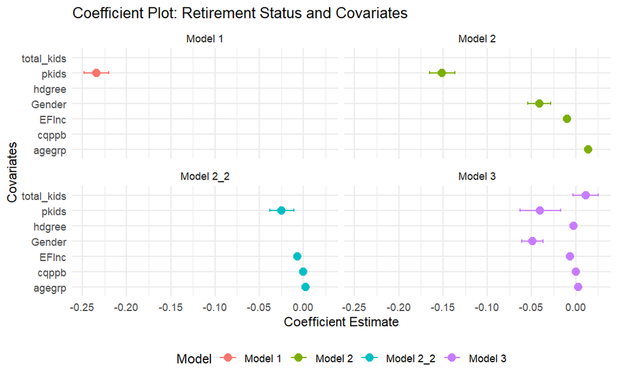

```r
# Load necessary libraries
library(broom)
# Extract regression results into a tidy format
tidy_model1 <- tidy(model1) %>% mutate(Model = "Model 1")
tidy_model2 <- tidy(model2) %>% mutate(Model = "Model 2")
tidy_model2_2 <- tidy(model2_2) %>% mutate(Model = "Model 2_2")
tidy_model3 <- tidy(model3) %>% mutate(Model = "Model 3")

# Combine all model results
all_models <- bind_rows(tidy_model1, tidy_model2, tidy_model2_2, tidy_model3)

# Filter out the intercept (we don't usually plot it)
all_models <- all_models %>% filter(term != "(Intercept)")

# Plot coefficient estimates
ggplot(all_models, aes(x = estimate, y = term, color = Model)) +
  geom_point(size = 3) +
  geom_errorbarh(aes(xmin = estimate - 1.96 * std.error,
                     xmax = estimate + 1.96 * std.error), height = 0.2) +
  facet_wrap(~ Model) +
  theme_minimal() +
  labs(title = "Coefficient Plot: Retirement Status and Covariates",
       x = "Coefficient Estimate",
       y = "Covariates") +
  theme(legend.position = "bottom")
```

### (b) Conditions for Causal Interpretation

For the estimates in each of our regressions to be interpreted causally—specifically, to infer that having children (`pkids`) causes a change in retirement status (`Retired`)—the following assumption of **strict exogeneity** must hold:

**Strict Exogeneity Assumption:**  
The regression error term must have zero conditional expectation given the explanatory variables included in the model:

$$E(\epsilon_i \mid \text{pkids}_i, X_i) = 0$$

Practically, this means:

- **No omitted variable bias:** All variables correlated both with having children (`pkids`) and retirement status (`Retired`) must be included in the model. If omitted variables remain, the strict exogeneity condition is violated.
- **No reverse causality:** Retirement status does not causally influence whether a family has children. Practically, this assumption is plausible here, as retirement typically occurs later in life, after childbearing decisions have already been made.

Thus, our causal interpretation requires believing that the included covariates (such as age, gender, household income, education level, family size, etc.) effectively control for all potential confounding factors, ensuring that:

$$E(\varepsilon_i | \text{pkids}_i, X_i) = 0$$

### (c) Implications for Omitted Variable Bias (OVB)

- **Model 1** (no covariates):
  $$\text{pkids coefficient} = -0.234$$
- **Model 2** (adding age group, gender, and income):
  $$\text{pkids coefficient} = -0.151$$
- **Model 3** (adding education, total kids, and pension income):
  $$\text{pkids coefficient} = -0.040$$

Specifically, the inclusion of critical covariates such as age, gender, household income, education level, and pension income substantially reduces the estimated effect, indicating that these variables were important omitted confounders in the simpler models.

However, with more covariates included, the R^2 kept increase; this is quite reasonable as with more covariate included, more parts of the total variance of retirement can be explained.

In conclusion, our analysis indicates substantial omitted variable bias in the simplest model, emphasizing the importance of controlling for comprehensive demographic and economic covariates to obtain a more accurate estimate of the true relationship.